# Assignment 1 - Review of Basic Statistical Concepts

**Created by John Palowitch, UNC Chapel Hill** # Amanda Liu PID:730042603

In this assignment, you will do Simple Random Sampling and simulation of random variables to illustrate statistical concepts and methods. **Be sure to title all axes and plots appropriately. You will lose points for plot or axes titles that are incorrect, ambiguous, or missing.**

**Part 1**

1. Into your working directory, you have placed two populations of size 10,000, “pop1.csv” and “pop2.csv”. Assume they each have mean $\mu = 5$ and standard deviation $\sigma = 4$. The first two lines in the codeblock below will load them into your **R** workspace once you have placed them in your working directory for **R**. The third line of code shows how to take an SRS of size 7.  
   Check the Normality of each population by taking a SRS of *size 100* (from each) and making appropriate plots. Which sample set appears more Normally distributed?

```r
#PUT YOUR CODE HERE. When you "knit" the file, output from your code will appear along with your code.

# Loading data
pop1 <- read.csv("pop1.csv")
pop2 <- read.csv("pop2.csv")
head(pop1)
```

```
##           V1
## 1 -0.1920567
## 2  0.2784973
## 3  4.5591141
## 4  5.9841560
## 5  6.4990812
## 6  2.6760339
```

```r
head(pop2)
```

```
##          V2
## 1 0.5833999
## 2 6.6425708
## 3 2.2334658
## 4 8.1376925
## 5 2.3552250
## 6 7.2303188
```

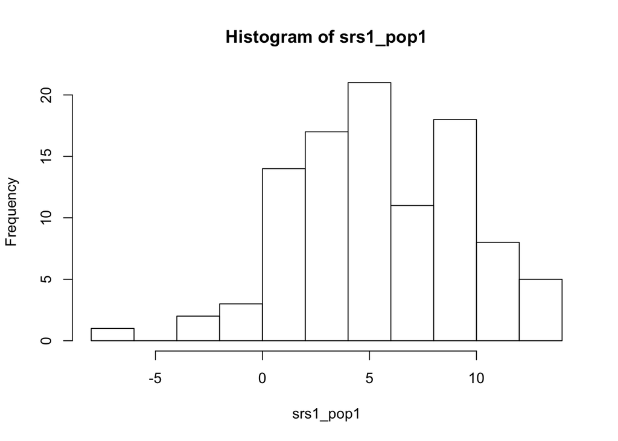

```r
#Take SRS of size n=7
srs1 <- sample(pop1$V1, 7, replace = FALSE)
srs1_pop1 <- sample(pop1$V1,100,replace = FALSE)
hist(srs1_pop1)
```

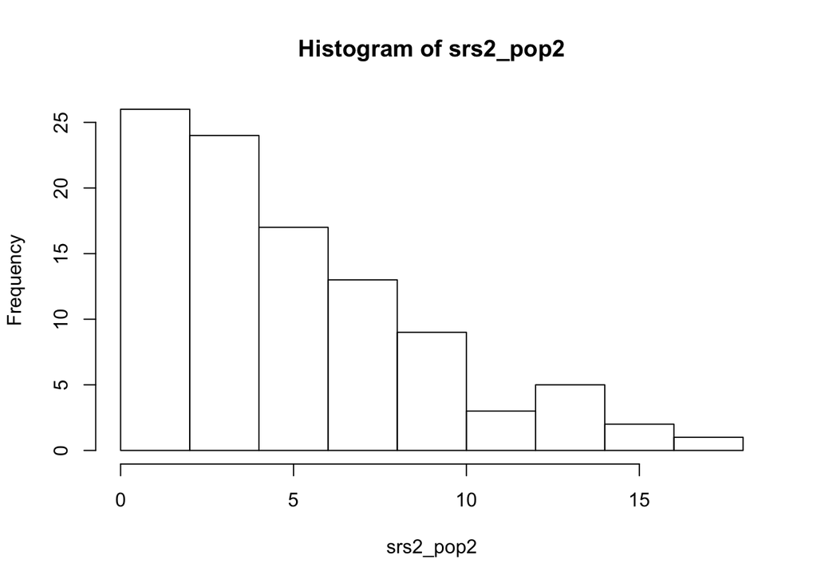

```
From the plots, pop1 is more normally distributed.
```

```r
srs2_pop2 <- sample(pop2$V2,100,replace = FALSE)
hist(srs2_pop2)
```

2. Suppose the data set that appears more Normal is in fact truly Normal with mean $\mu = 5$ and standard deviation $\sigma = 4$. Consider the random variable $\bar x$ from a SRS of size 5 from population 1. On a separate sheet of paper, write down $\bar x$’s mean, variance, and anything we can say about its distribution. Then, check the distribution of $\bar x$ by doing the following:
   1. Take 1,000 simple random samples of size $n = 5$ from population 1. Calculate $\bar x$ from each and store the value in a vector containing all of the $\bar x$’s. *(You can answer this part by modifying the code in the box below)*
   2. Make an appropriate plot for your 1,000 $\bar x$’s to assess their distribution.***(You will have to add your own code to the box below to answer this part.)
   3. In the answer box below, write whether or not the plot you made showed what you expected, and why.

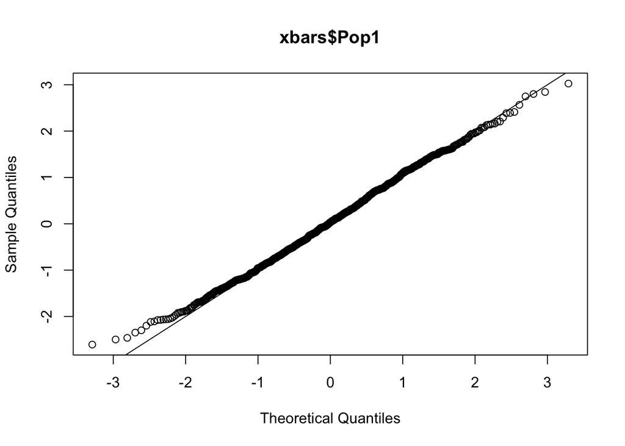

[output not shown]

```r
n <- 5
nsims <- 1000

# Define vector of sample means as a numeric vector and give it length equal to 'nsims'
xbars <- numeric(nsims)

# Take 1000 samples of size n and record means in the vector. The result is a vector containing 1000 sample means.
for(i in 1:nsims){

  xbars[i] <-mean(sample(pop1$V1,n,replace = FALSE))

}
zs<-(xbars-5)/(4/sqrt(n))
qqnorm(zs,main="xbars$Pop1")
abline(0,1)
```

3. What can we say about the sampling distribution of $\bar x$ from a SRS of size 5 from population 2? This time, make your own ‘written answer box’ and write down the sampling distribution’s mean, variance, and anything else you can say about it. Then repeat parts a.-c. from question 2.

```r
n <- 5
nsims <1000
```

```
## [1] FALSE
```

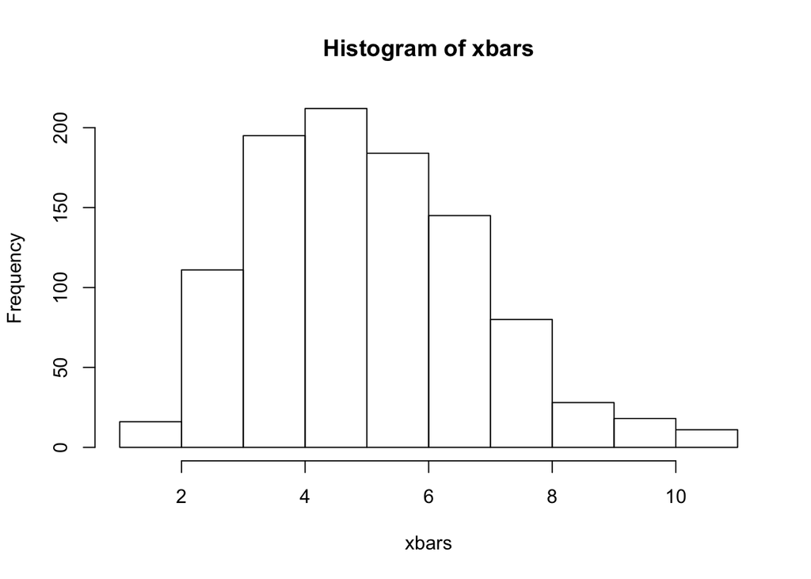

```r
xbars <- numeric(nsims)


for(i in 1:nsims){

  xbars[i] <- mean(sample(pop2$V2,n,replace=FALSE))

}
hist(xbars)
```

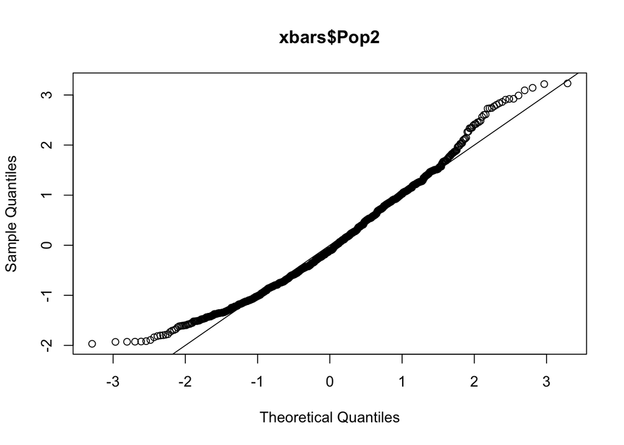

[output not shown]

```r
zs<-(xbars-5)/(4/sqrt(n))
qqnorm(zs,main="xbars$Pop2")
abline(0,1)
```

4. The Central Limit Theorem suggests that even for highly non-Normal populations, taking large samples makes $\bar x$ approximately Normal.
   1. In a new written-answer box, write the “rule-of-thumb” conditions on sample size which validates use of the Central Limit Theorem for statistical inference.
   2. There is also a rule-of-thumb for taking a *small enough* SRS, with respect to the population size. If the population size is $N$, then in your answer box, write down the largest sample size $n$ which satisfies both rule-of-thumb conditions.
   3. Verify that these are good rules by repeating questions 2a-2c with population 2, but this time with the largest appropriate sample size. *(You should re-do 3a-3c in a new codeblock below and in a new written answer box; don’t change your answers to question 3.)*

```
a. sample size: n>30
```

```
b. sample size: n<0.1(N),
   N: population size
```

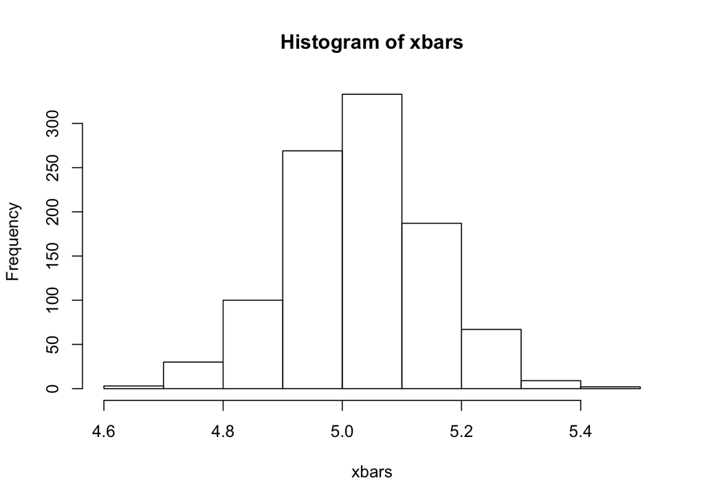

```r
n <- 0.1*10000
nsims <- 1000

xbars <- numeric(nsims)

for(i in 1:nsims){

  xbars[i] <- mean(sample(pop2$V2,n,replace=FALSE)) #YOUR CODE IN PLACE OF "0"

}
hist(xbars)
```

*Using `rnorm` to generate random variables is just like taking a SRS from a closely-Normal population (like population 1). For the rest of the assignment, you will use `rnorm` to simulate SRS’s from a Normal population.*

5. Access the documentation in R-Studio by entering the command ‘?rnorm’. Use this documentation and your ingenuity to simulate 20 random draws from a normal population with mean $\mu=50$ and standard deviation $\sigma=6$. Your answer, when ‘knit’, should show your code and the output from the code.

```r
rnorm(20,50,6)
```

```
##  [1] 52.26654 46.02787 43.07122 45.57540 53.44822 41.82538 48.14320
##  [8] 40.80549 57.89827 49.10321 47.46010 55.69380 55.67481 50.82830
## [15] 57.27656 54.19084 45.75283 51.22688 52.91424 39.01183
```

6. In problems 1-3, we investigated basic properties of the sample mean $\bar x$. In this problem we’ll investigate the sample variance $\hat\sigma^2=s^2$.
   1. I mentioned in class that
      $$s^2 = \dfrac{\sum_i (X_i - \bar X)^2}{n - 1}$$
      is an unbiased estimate for $\sigma^2$, the population variance. If you have had STOR 215 and are mathematically inclined, you should read [this proof](http://pascencio.cos.ucf.edu/classes/Methods/Proof%20that%20Sample%20Variance%20is%20Unbiased.pdf). *(No work to submit for this part.)*
   2. For each integer $n$ in the interval [10, 400], do the following: i. simulate a Normal SRS with sample size $n$, $\mu = 5$ and $\sigma = 4$, and calculate $s^2$ for the sample, then ii. store the calculated in a vector with the other calculated values of $s^2$). iii. Then make a scatterplot of $s^2$ vs. $n$. iv. Finally draw the line $y = \sigma^2$ on the plot. (Hint 1. `For (n in 10:400) {...}` Hint 2: Use `curve()`)

*(Your answer should include code and its output.)*

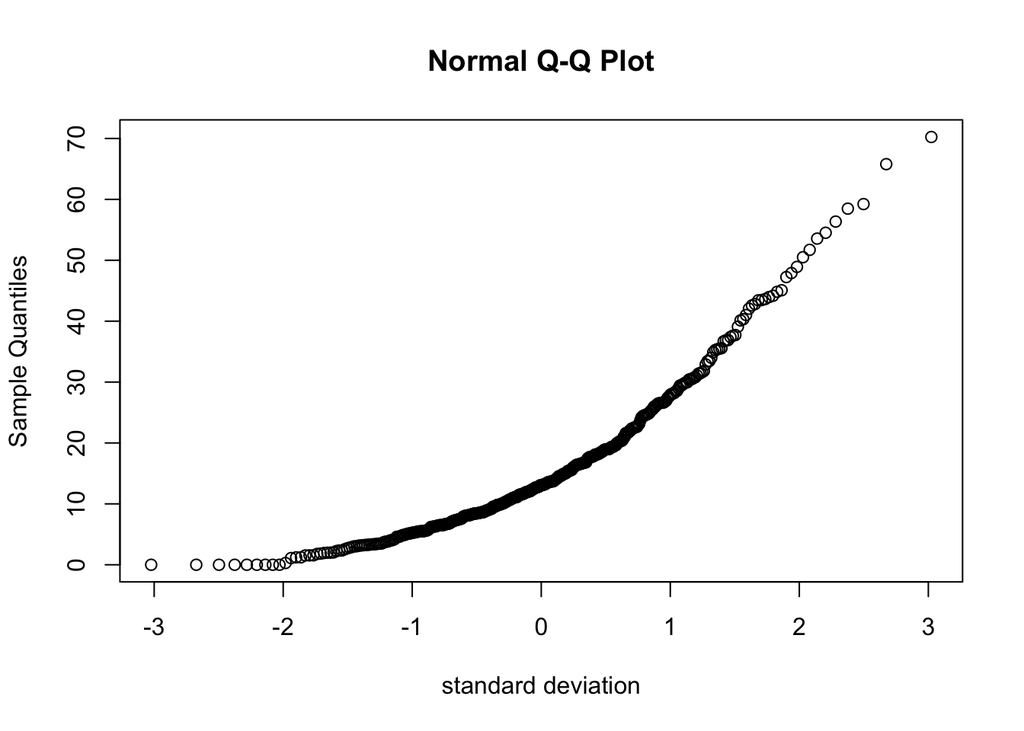

```r
#Your code here
n=5
sigma=4
length=10:400
nsims=391
vars=numeric(nsims)
for(i in 10:400){
  srsn=rnorm(i, mean=5,sd=4)
  vars[i]=var(sample(srsn,n,replace = FALSE))
}
qqnorm(vars,xlab = "standard deviation")
```

c. In an answer box below, describe what is happening to $s^2$ as $n$ gets larger and larger. Explain why this happens. Approximately what value would you expect for $s^2$ for a sample size of 1,000,000 (Explain)?